# CWRU DSCI351-351M-451: Week01a-p R Intro, (CWRU, Pitt, UCF, UTRGV)

Profs: R. H. French, L. S. Bruckman, P. Leu, K. Davis, S. Cirlos

TAs: W. Oltjen, K. Hernandez, M. Li, M. Li, D. Colvin

06 September, 2022

##### Foundations, Practicum and Advanced

- Foundation Topics are the background fundamentals
- Practicum is real coding and data analysis
- Advanced are introductions to advanced topics

#### Syllabus

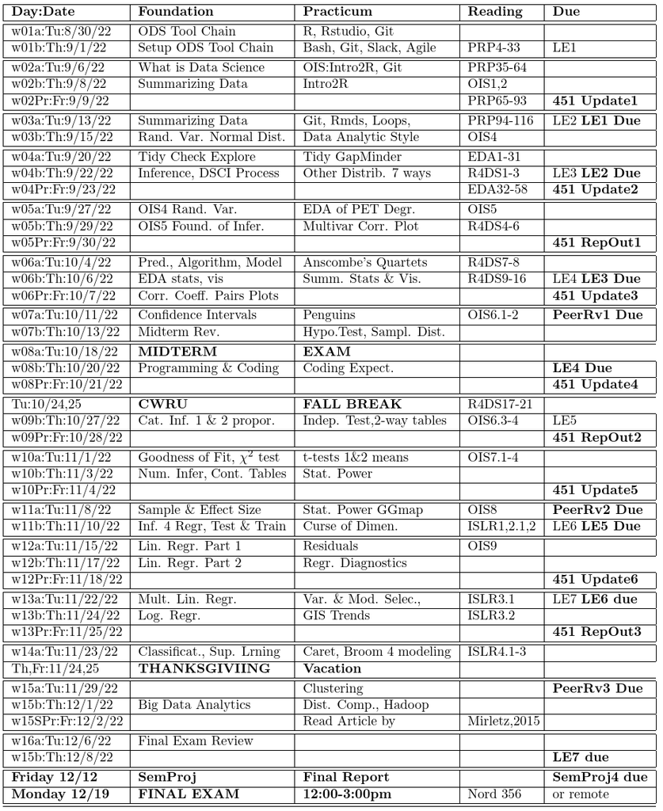

DSCI351-351M-451 Syllabus

- License: [CC-BY-SA 4.0](https://creativecommons.org/licenses/by-sa/4.0/)

##### setup for r-code chunks

```r
  options("digits" = 5)
  options("digits.secs" = 3)
```

#### A Simple Overview of R

- We’ll look in more detail, going forward

##### Intro to some R: Data Types

- Primitives (numeric, integer, character, logical, factor)
- Data Frames
- Lists
- Tables
- Arrays
- Environments
- Others (functions, closures, promises..)

##### Simple Types, and their class

```r
  x <- 1
  class(x)
```

```
[1] "numeric"
```

```r
  y <- "Hello World"
  class(y)
```

```
[1] "character"
```

```r
  z <- TRUE
  class(z)
```

```
[1] "logical"
```

```r
  as.integer(z)
```

```
[1] 1
```

##### Simple Types - Vectors

- The basic type unit in R is a vector

```r
  x <- c(1,2,3)
  x
```

```
[1] 1 2 3
```

```r
  x <- 1:3
  x[1]
```

```
[1] 1
```

```r
  x[0]
```

```
integer(0)
```

```r
  x[-1]
```

```
[1] 2 3
```

##### Generating Vectors

- R provides lots of convenience functions for data generation:

```r
  rep(0, 5)
```

```
[1] 0 0 0 0 0
```

```r
  seq(1,10)
```

```
 [1]  1  2  3  4  5  6  7  8  9 10
```

```r
  seq(1,2,.1)
```

```
 [1] 1.0 1.1 1.2 1.3 1.4 1.5 1.6 1.7 1.8 1.9 2.0
```

```r
  seq(1,2,length.out = 6)
```

```
[1] 1.0 1.2 1.4 1.6 1.8 2.0
```

##### Indexing, c is concatenate

- to see the help on c: help(c)

```r
  x <- c(1, 3, 4, 10, 15, 20, 50, 1, 6)
  x > 10
```

```
[1] FALSE FALSE FALSE FALSE  TRUE  TRUE  TRUE FALSE FALSE
```

```r
  which(x > 10)
```

```
[1] 5 6 7
```

```r
  x[x > 10]
```

```
[1] 15 20 50
```

```r
  x[!x > 10]
```

```
[1]  1  3  4 10  1  6
```

```r
  x[x <= 10]
```

```
[1]  1  3  4 10  1  6
```

```r
  x[x > 10 & x < 30]
```

```
[1] 15 20
```

##### Functions, very easy to define

- Usually take code in scripts, make functions from them

```r
  square <- function(x) x^2
  square(2)
```

```
[1] 4
```

```r
  pow <- function(x, p=2) x^p
  pow(10)
```

```
[1] 100
```

```r
  pow(10,3)
```

```
[1] 1000
```

```r
  pow(p = 3,10)
```

```
[1] 1000
```

- Functions can be passed as data:

```r
  g <- function(x, f) f(x)
  g(10, square)
```

```
[1] 100
```

```r
  h <- function(x,f,...) f(x,...)
  h(10, pow, 3)
```

```
[1] 1000
```

##### R is Vectorized

- Example - multiplying two vectors:

```r
  mult <- function(x,y) {
    z <- numeric(length(x))
    for (i in 1:length(x)) {
      z[i] <- x[i] * y[i]
      }
    z
    }

  mult(1:10,1:10)
```

```
 [1]   1   4   9  16  25  36  49  64  81 100
```

##### R is Vectorized

- Multiplying two vectors ‘the R way’:

```r
  1:10 * 1:10
```

```
 [1]   1   4   9  16  25  36  49  64  81 100
```

- NOTE: R recycles vectors of unequal length:

```r
  1:10 * 1:2
```

```
 [1]  1  4  3  8  5 12  7 16  9 20
```

##### NOTE: Random Number Generation

- R contains a huge number of
  - built-in random number generators
  - for various probability distributions

```r
# Normal variates, mean=0, sd=1
  rnorm(10)
```

```
 [1]  0.418526  1.729563  0.103367 -0.507603  0.254677  0.054482
 [7] -0.630555  0.267043 -0.497756 -0.203316
```

```r
  rnorm(10, mean = 100, sd = 5)
```

```
 [1]  99.854 101.901 100.487 110.725  86.605 106.751 107.464
 [8] 101.682 102.663  94.646
```

- Many different distributions available

#### Data Frames

##### Data Frames are fundamental

- Data frames are the fundamental structure
  - used in data analysis
  - Similar to a database table in spirit
  - (named columns, distinct types)

```r
  d <- data.frame(x = 1:6, y = "AUDUSD", z = c("one","two"))
  d
```

| x | y | z |
| --- | --- | --- |
| 1 | AUDUSD | one |
| 2 | AUDUSD | two |
| 3 | AUDUSD | one |
| 4 | AUDUSD | two |
| 5 | AUDUSD | one |
| 6 | AUDUSD | two |

##### Data Frames can be indexed

- Data frames can be indexed like a vector or matrix:

```r
  # First row
  d[1,]
```

|  | x | y | z |
| --- | --- | --- | --- |
| 1 | 1 | AUDUSD | one |

```r
  # First column
  d[,1]
```

```
[1] 1 2 3 4 5 6
```

```r
  # First and third cols, first two rows
  d[1:2,c(1,3)]
```

|  | x | z |
| --- | --- | --- |
| 1 | 1 | one |
| 2 | 2 | two |

##### Generate a Data Frame

- Let’s generate some dummy data:
  - Using data.frame

```r
  generateData <- function(N) data.frame(time = Sys.time() + 1:N,
    sym = "AUDUSD",
    bid = rep(1.2345,N) + runif(min = -.0010,max = .0010,N),
    ask = rep(1.2356,N) + runif(min = -.0010,max = .0010,N),
    exch = sample(c("EBS","RTM","CNX"),N, replace = TRUE))

  prices <- generateData(50)
  head(prices, 5)
```

|  | time | sym | bid | ask | exch |
| --- | --- | --- | --- | --- | --- |
| 1 | 2022-09-06 12:42:30.952 | AUDUSD | 1.2349 | 1.2362 | EBS |
| 2 | 2022-09-06 12:42:31.952 | AUDUSD | 1.2339 | 1.2355 | CNX |
| 3 | 2022-09-06 12:42:32.952 | AUDUSD | 1.2348 | 1.2358 | CNX |
| 4 | 2022-09-06 12:42:33.952 | AUDUSD | 1.2339 | 1.2360 | RTM |
| 5 | 2022-09-06 12:42:34.952 | AUDUSD | 1.2352 | 1.2353 | CNX |

##### Data Frames

- We can add/remove columns on the fly:

```r
  prices$spread <- prices$ask - prices$bid
  prices$mid <- (prices$bid + prices$ask) * 0.5
  head(prices)
```

|  | time | sym | bid | ask | exch | spread | mid |
| --- | --- | --- | --- | --- | --- | --- | --- |
| 1 | 2022-09-06 12:42:30.952 | AUDUSD | 1.2349 | 1.2362 | EBS | 0.00131140 | 1.2355 |
| 2 | 2022-09-06 12:42:31.952 | AUDUSD | 1.2339 | 1.2355 | CNX | 0.00155201 | 1.2347 |
| 3 | 2022-09-06 12:42:32.952 | AUDUSD | 1.2348 | 1.2358 | CNX | 0.00100148 | 1.2353 |
| 4 | 2022-09-06 12:42:33.952 | AUDUSD | 1.2339 | 1.2360 | RTM | 0.00210514 | 1.2350 |
| 5 | 2022-09-06 12:42:34.952 | AUDUSD | 1.2352 | 1.2353 | CNX | 0.00011217 | 1.2352 |
| 6 | 2022-09-06 12:42:35.952 | AUDUSD | 1.2351 | 1.2364 | RTM | 0.00132323 | 1.2358 |

##### Operations on Data Frames

- Some basic operations on data frames:

```r
  names(prices)
```

```
[1] "time"   "sym"    "bid"    "ask"    "exch"   "spread" "mid"
```

```r
  table(prices$exch)
```

```
CNX EBS RTM
 16  24  10
```

```r
  summary(prices$mid)
```

```
   Min. 1st Qu.  Median    Mean 3rd Qu.    Max.
   1.23    1.23    1.24    1.24    1.24    1.24
```

##### These Operators Are Functions

```r
  `(`
```

```
.Primitive("(")
```

```r
  (1 + 2)
```

```
[1] 3
```

```r
  `(` <- function(x) 42
  (1 + 2)
```

```
[1] 42
```

```r
  rm("(")
```

#### Examples in R

##### Example: Median Absolute Deviation

$$MAD(x) = median\left(\left|Y_i -
\hat{Y}\right|\right)$$

```r
  mad
```

```
function (x, center = median(x), constant = 1.4826, na.rm = FALSE,
    low = FALSE, high = FALSE)
{
    if (na.rm)
        x <- x[!is.na(x)]
    n <- length(x)
    constant * if ((low || high) && n%%2 == 0) {
        if (low && high)
            stop("'low' and 'high' cannot be both TRUE")
        n2 <- n%/%2 + as.integer(high)
        sort(abs(x - center), partial = n2)[n2]
    }
    else median(abs(x - center))
}
<bytecode: 0x5581ad33ff38>
<environment: namespace:stats>
```

##### Example: Simulating Coin Tosses

- What is the probability of
  - exactly 3 heads in 10 coin tosses
  - for a fair coin?

*Using binomial identity:*

$$\binom{n}{k}p^{k}(1-p)^{(n-k)}
= \binom{10}{3}\left(\frac{1}{2}\right)^{3}\left(\frac{1}{2}\right)^{7}$$

```r
  choose(10,3)*(.5)^3*(.5)^7
```

[output not shown]

*Using binomial distribution density function:*

```r
 dbinom(prob = 0.5, size = 10, x = 3)
```

```
[1] 0.11719
```

*Using simulation (100,000 tosses):*

```r
  sum(replicate(100000,sum(rbinom(prob = 1/2, size = 10, 1)) == 3))/100000
```

```
[1] 0.11494
```

##### Example: Random Walk

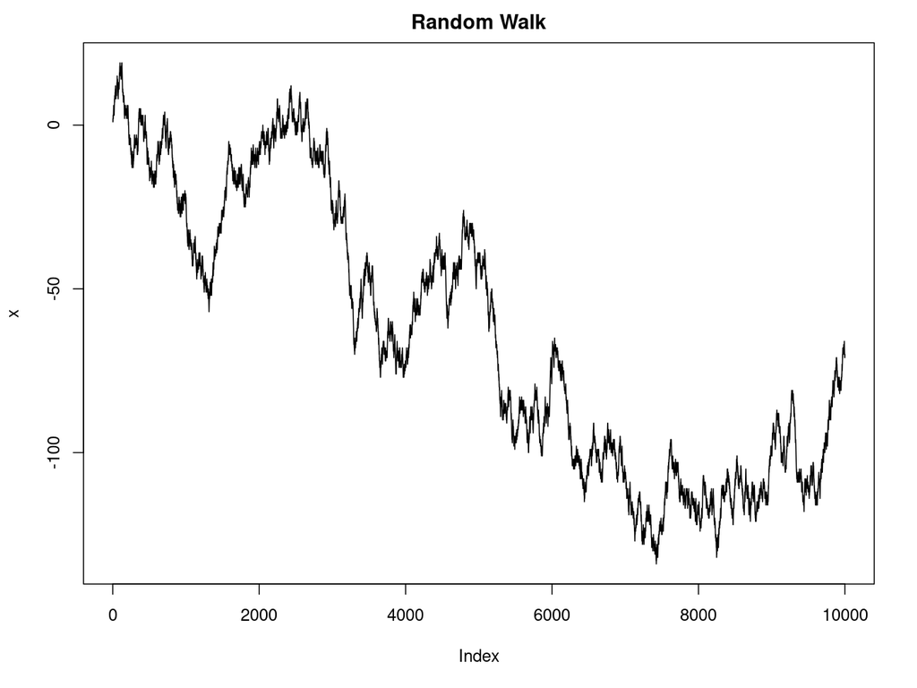

```r
  x <- (cumsum(ifelse(rbinom(prob = 0.5, size = 1, 10000) == 0,-1,1)))
  plot(x, type = 'l', main = 'Random Walk')
```

##### Example: Generating Random Data

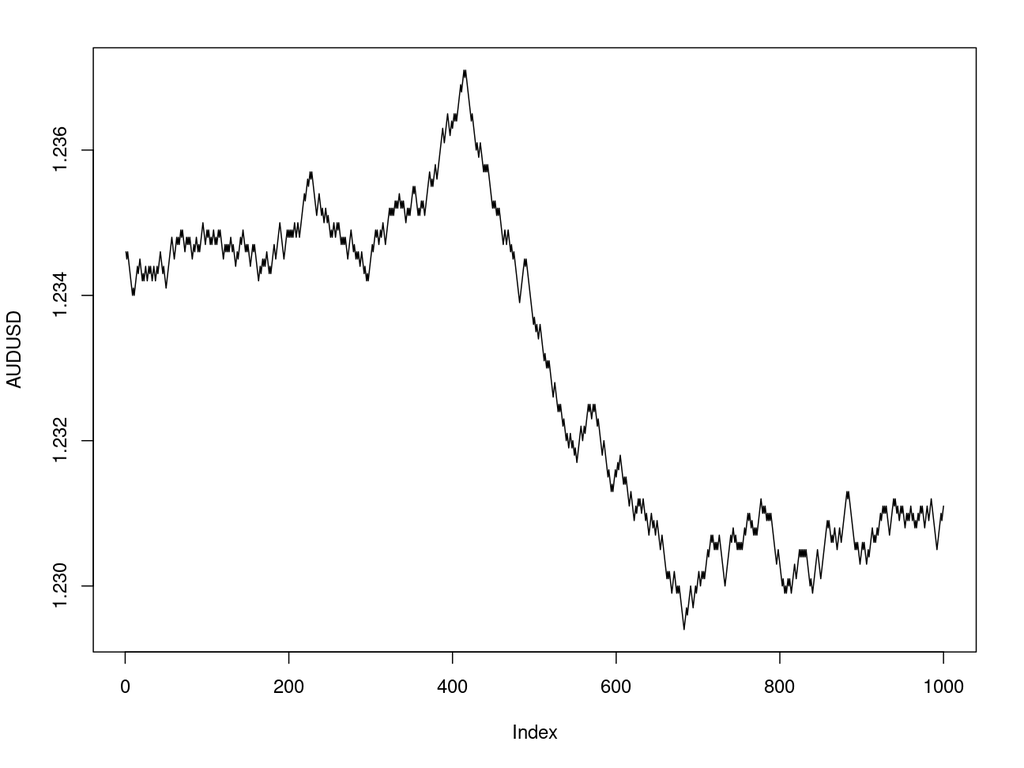

```r
  randomWalk <- function(N)(cumsum(ifelse(rbinom(prob = 0.5, size = 1, N) == 0,-1,1)))
  AUDUSD <- 1.2345 + randomWalk(1000)*.0001

  plot(AUDUSD, type = 'l')
```

```r
NA
```

##### Example: Reading Log Data From File

```r
  # Read file into data frame
  logfile <- read.csv("/tmp/application.log", sep=",", header=FALSE)
  # Set column descriptors
  colnames(logfile) <- c("time","message","severity")
  # Convert to native date/time
  logfile$time <- as.POSIXct(strptime
                    (logfile$time, "%Y-%m-%d %H:%M:%OS"), tz="GMT")
```

##### Example: Using already existing Datasets

- The famous ‘Air passengers’ dataset

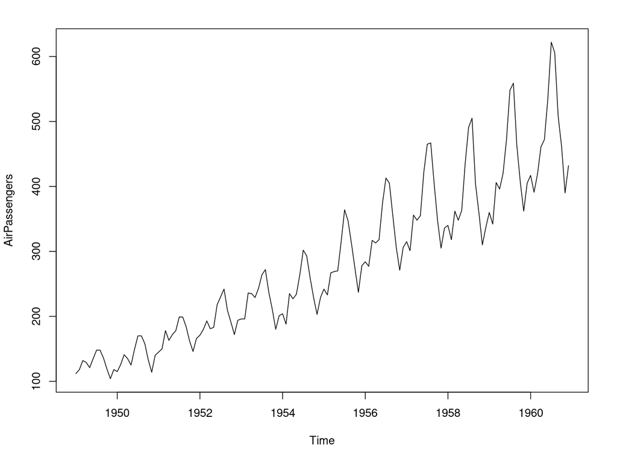

```r
  plot(AirPassengers)
```

##### Example: Using Datasets:

- ‘Anscombe Quartet’:4 x-y datasets, same stats props, Yet quite different.

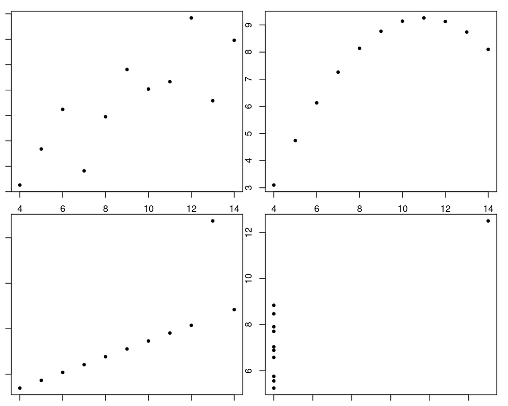

```r
  op <- par(mfrow = c(2,2),mar = rep(1,4))
  with(anscombe,{plot(x1,y1,pch = 20);plot(x2,y2,pch = 20);
                 plot(x3,y3,pch = 20);plot(x4,y4,pch = 20)})
  par(op)
```

##### Links

- http://www.r-project.org
- Rory Winston, for the Learning R intro
  - http://www.theresearchkitchen.com/archives/1017
- kdb+ is an online database of open time-series data
  - http://kx.com/kdb-plus.php